# Georgetown College XCTF 2022-2023

# Latest Update

- 2022 Cross Country Schedule Update

Updated on: Thu Jun 30 1:56:40 PM 2022

# 2022-2023 Information

## Calendar

Click HERE For Pace Distance Runner charts!

Travel Release form Download

[Missed Practice Request Form](https://forms.gle/RNQ7pa1RwmE6e2ncA)

Select a month or group below:

### Meets

| Date | Day | Event | Host | Location | Time | Type | Note |
| --- | --- | --- | --- | --- | --- | --- | --- |
| 2022-09-02 | Friday | BCCC Jamboree | Berea College and Centre College | Berea, KY | TBA | Meet | 2mile / 5k |
| 2022-09-17 | Saturday | Mike and Mary Kay Johnson Invitational | Berea College | Berea, KY | TBA | Meet |  |
| 2022-10-01 | Saturday | Live In Lou Cross Country Classic Classic | Louisville Sports Commission | E.P. Tom Sawyer Park, Louisville, KY | TBA | Meet | Top 10 Only |
| 2022-10-07 | Friday | Brescia University Invitational | Brescia University | Yellow Creek Park, Owensboro, KY | TBA | Meet | 11th+ Only |
| 2022-10-14 | Friday | Jenna Strong Fall Classic | Wilmington College | Wilmington, OH | TBA | Meet |  |
| 2022-10-22 | Saturday | NAIA Great Lakes Challenge | Aquinas College | Grand Rapids, MI | TBA | Meet |  |
| 2022-11-04 | Friday | MSC Championships | Mid-South Conference | Phil More Park, Bowling Green, KY | TBA | Meet |  |
| 2022-11-18 | Friday | NAIA National Championships | NAIA | Tallahassee, FL | TBA | Meet |  |

### Feb

| Date | Day | Event | Host | Location | Time | Type | Note |
| --- | --- | --- | --- | --- | --- | --- | --- |

### March

| Date | Day | Event | Host | Location | Time | Type | Note |
| --- | --- | --- | --- | --- | --- | --- | --- |

### April

| Date | Day | Event | Host | Location | Time | Type | Note |
| --- | --- | --- | --- | --- | --- | --- | --- |

### May

| Date | Day | Event | Host | Location | Time | Type | Note |
| --- | --- | --- | --- | --- | --- | --- | --- |

### Practice Results

| Date | Day | Event | Host | Location | Time | Type | Note |
| --- | --- | --- | --- | --- | --- | --- | --- |

## XC Class Schedule Summary

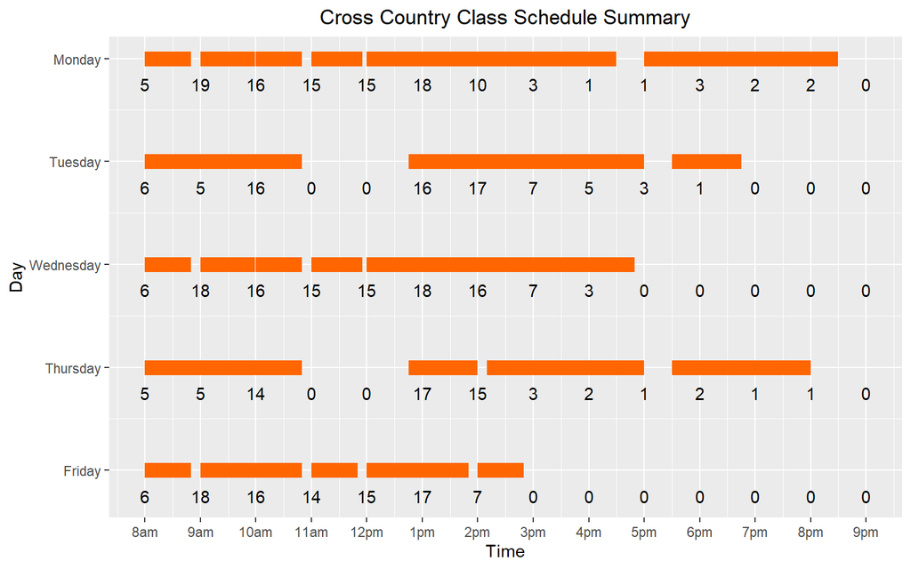

## Freshmen Info

Freshmen: two major things need to be completed by August 1st

### PlayNAIA

All freshmen are required to register with the NAIA Eligibility Center at the following link: [PlayNAIA](https://play.mynaia.org/)

The NAIA charges a 1 time fee around $100 that GC is not allowed to cover and you will be required to send in transcripts. PLEASE GET YOUR END OF THIS TAKEN CARE OF BEFORE AUGUST 1st!!!!! Once you have sent in the required documents it can take a few weeks for the NAIA to review and clear you to compete. So this needs to be done ASAP!

Once you register, you will be assigned an NAIA-ID number. Please let me know what that number.

### Insurance Information and Physicals

Stacee Gibson from Athletic Training should have sent you Insurance form information to you Georgetown College Email. PLEASE GET THIS DONE BEFORE July 14th!

If you have any issues with the forms, please email Stacee at: stacee_gibson@georgetowncollege.edu

Physicals will be FREE and they must be performed by a doctors that GC’s insurance has approved in order for you to be covered by GC insurance. (We are partnered with UK Healthcare, so you will be seen by UK Healthcare doctors) Your physical cannot be completed unless you have filled out the forms!